# 宮城県 (議員定数：6 → 5)

アルゴリズムによる衆議院小選挙区の区割り改定案

ALARM Japan プロジェクトチーム  
2022/04/14

**宮城県**

人口： 2,282,543 人（2020年）

|  | 現行 | アルゴリズムの提案 市区町村の分割無し | アルゴリズムの提案 最大市区町村の分割可 |
| --- | --- | --- | --- |
| **1票の格差** |  |  |  |
| 県内較差 | 1.941 | 1.044 | 1.044 |
| 改善率 | - | 95.4% | 95.4% |
| **選挙区の状況** |  |  |  |
| 選挙区数 | 6 | 5 | 5 |
| 市区町村の分割 | 2<sup>a</sup> | 0 | 0 |
| 郡の分割 | 2<sup>b</sup> | 2<sup>b</sup> | 2<sup>b</sup> |
| 広域連携地域の分割 | 1<sup>c</sup> | 1<sup>c</sup> | 1<sup>c</sup> |

<sup>*a*</sup> 仙台市太白区、大崎市 <sup>*b*</sup> 宮城郡、黒川郡 <sup>*c*</sup> 大崎定住自立圏

# 現行の区割り

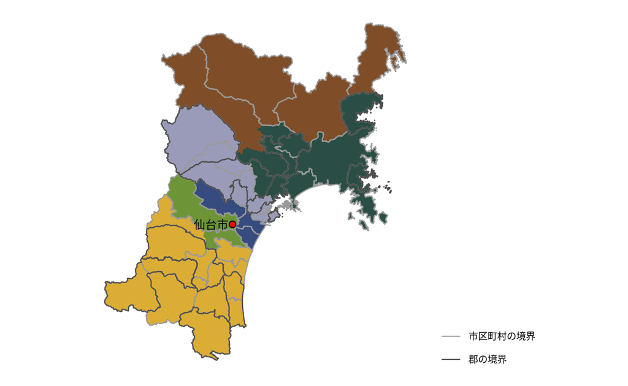

# アルゴリズムの提案

アルゴリズムが提案した25,000案のうち、有効な案の中で、一票の格差が最小のもの

### 市区町村を分割しない区割り案

一票の格差 : 1.044

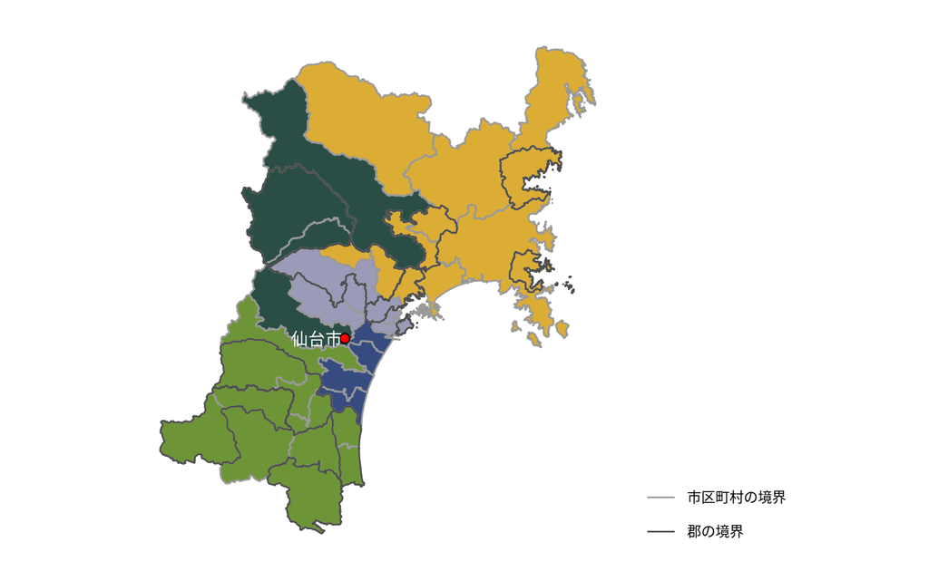

### 最大市区町村の分割を許容する区割り案

人口が最大の市区町村 : 石巻市

一票の格差 : 1.044

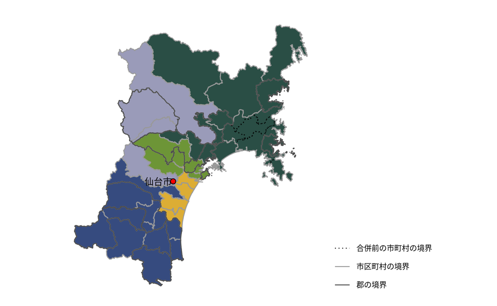

# 共起分析

- アルゴリズム設定
  - 市区町村の分割無し
  - 飛び地を含む案を棄却
  - 一票の格差が下位10％の案を抽出
- 読み取り方  
  地図上の市区町村の色が
  - 同じ → 同じ選挙区に属する傾向が強い
  - 同じ かつ 濃い → 隣接する市区町村と同じ選挙区に属する傾向が強い

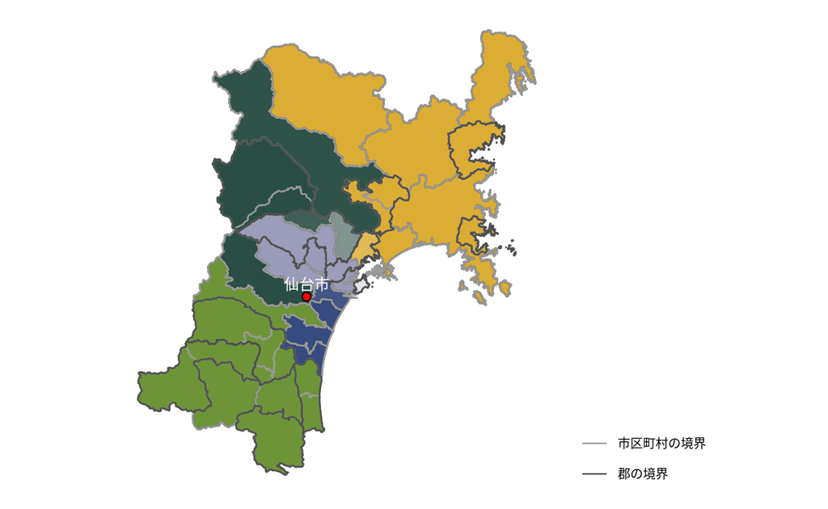

# アルゴリズム設定

- 各選挙区の人口 : (県内の日本人人口 / 選挙区数) ±10%
  - サンプリング効率が80%~100%となるように調節
- 市区町村分割を許容しない案、及び日本人人口が最大の市（政令指定都市の行政区を除く）の分割を許容する案の2種類を作成
  - 最大市区町村を分割する際は、平成の大合併以前の市区町村界に基づく
  - 旧市区町村単位の人口（総人口-外国人人口）は、合併後の市区町村の人口（総人口-外国人人口）と旧市区町村単位の日本人人口を元に推計
- 郡の分割は、現行の区割りにて分割されている場合のみ許容
- 離島は、航路で結ばれている本土の市区町村と同一の選挙区にする
- 市区町村分割を許容しない案、最大市区町村の分割を許容する案をそれぞれ25,000作成
- 以下の案を棄却し有効な案を選定
  - 飛び地が生じる案
  - 市区町村が3つ以上の選挙区に分割される案
- 有効な案の中から5,000の案を無作為に抽出

[**データをダウンロード**](https://doi.org/10.7910/DVN/Z9UKSH)

### 県特有の設定

- 宮城野区港５丁目は厳密には飛び地とみなすこともできるが、現行の区割りでは飛び地として扱われていないため、本プロジェクトでも飛び地として扱わない。